# p8105_hw1_rc3520

Ruyi Chen

2023-09-23

```r
library (tidyverse)
```

#Problem 1

```r
library(moderndive)
data("early_january_weather")
```

## Description of the early_january_weather data set

1. This data set has 358 rows, and 15 columns.
2. Origin represents weather station; Year, month, day and hour represent time of recording;temp and dewp represent temperature and dewpoint in F; humid represents relative humidity; wind_dir, wind_speed and wind_gust represent wind direction (in degrees), speed and gust speed (in mph); precip represents precipitation, in inches; pressure represents sea level pressure in millibars; visib represents visibility in miles; time_hour represents date and hour of the recording as a POSIXct date.
3. The mean temperature is 39.5821229.

##Make a scatterplot of temp (y) vs time_hour (x)

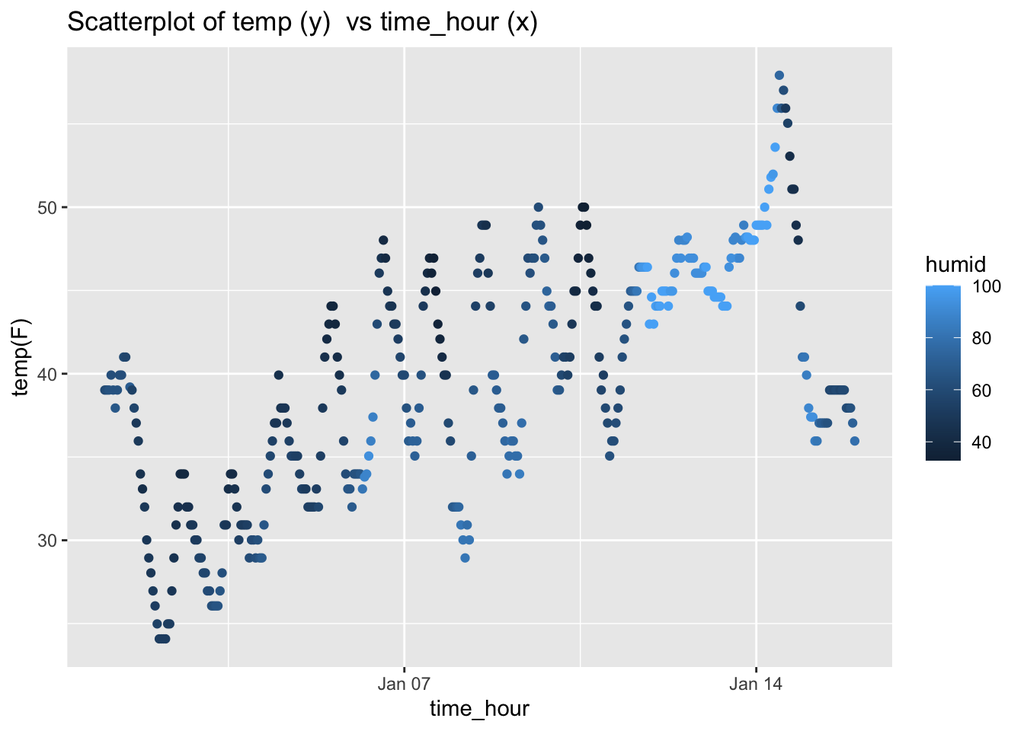

```r
ggplot(early_january_weather, aes(x = time_hour, y = temp, color=humid)) +
  geom_point() +
  ggtitle('Scatterplot of temp (y)  vs time_hour (x)') +
  xlab('time_hour') + ylab('temp(F)')
```

## Export the scatterplot to project directory

```r
ggsave("Scatterplot of temp(y) vs time_hour(x).pdf")
```

# Problem 2

## Create a data frame

```r
problem2_df = tibble(
  nrom = rnorm(10, mean = 0, sd = 1),
  logi_vector = nrom > 0,
  char_vector = c("a", "b", "c", "d", "e", "f", "g", "h", "i", "j"),
  fac_vector = factor(c("High", "Medium", "Low", "High", "High", "High", "Low", "Low", "Low", "Medium"))
)
view(problem2_df)
```

## Calculate the mean of variables in the dataframe

```r
nrom_mean = mean(pull(problem2_df, var = nrom))
nrom_mean
```

```
## [1] -0.5081267
```

```r
logi_vector_mean = mean(pull(problem2_df, var = logi_vector))
logi_vector_mean
```

```
## [1] 0.3
```

```r
char_vector_mean = mean(pull(problem2_df, var = char_vector))
char_vector_mean
```

```
## [1] NA
```

```r
fac_vector_mean = mean(pull(problem2_df, var = fac_vector))
fac_vector_mean
```

```
## [1] NA
```

Answer: *mean* function only works on nrom and logical vector but doesn’t work on character vector and factor vector.

## Apply the as.numeric function to the logical, character, and factor variables

```r
convert_logi_vector = as.numeric(pull(problem2_df, var = logi_vector))
convert_logi_vector
convert_char_vector = as.numeric(pull(problem2_df, var = char_vector))
convert_char_vector
convert_fac_vector = as.numeric(pull(problem2_df, var = fac_vector))
convert_fac_vector
```

[output not shown]

Answer: Applying the as.numeric function to the logical and factor variables is successful; however, it doesn’t work successfully on character vector, showing that characters cannot be converted into numbers. And logical and factor variables can be converted into numbers and be used in other calculations.